# Tarea_Programada_02_JimenaRamirez

Jimena Ramirez Zamora

2024-06-09

instalar los paquetes

```r
library(dplyr)
library(rmarkdown)
datos_mtcars<-mtcars
str(mtcars)
```

```
## 'data.frame':    32 obs. of  11 variables:
##  $ mpg : num  21 21 22.8 21.4 18.7 18.1 14.3 24.4 22.8 19.2 ...
##  $ cyl : num  6 6 4 6 8 6 8 4 4 6 ...
##  $ disp: num  160 160 108 258 360 ...
##  $ hp  : num  110 110 93 110 175 105 245 62 95 123 ...
##  $ drat: num  3.9 3.9 3.85 3.08 3.15 2.76 3.21 3.69 3.92 3.92 ...
##  $ wt  : num  2.62 2.88 2.32 3.21 3.44 ...
##  $ qsec: num  16.5 17 18.6 19.4 17 ...
##  $ vs  : num  0 0 1 1 0 1 0 1 1 1 ...
##  $ am  : num  1 1 1 0 0 0 0 0 0 0 ...
##  $ gear: num  4 4 4 3 3 3 3 4 4 4 ...
##  $ carb: num  4 4 1 1 2 1 4 2 2 4 ...
```

summary para crear un resumen de los datos

```r
summary(mtcars)
```

```
##       mpg             cyl             disp             hp
##  Min.   :10.40   Min.   :4.000   Min.   : 71.1   Min.   : 52.0
##  1st Qu.:15.43   1st Qu.:4.000   1st Qu.:120.8   1st Qu.: 96.5
##  Median :19.20   Median :6.000   Median :196.3   Median :123.0
##  Mean   :20.09   Mean   :6.188   Mean   :230.7   Mean   :146.7
##  3rd Qu.:22.80   3rd Qu.:8.000   3rd Qu.:326.0   3rd Qu.:180.0
##  Max.   :33.90   Max.   :8.000   Max.   :472.0   Max.   :335.0
##       drat             wt             qsec             vs
##  Min.   :2.760   Min.   :1.513   Min.   :14.50   Min.   :0.0000
##  1st Qu.:3.080   1st Qu.:2.581   1st Qu.:16.89   1st Qu.:0.0000
##  Median :3.695   Median :3.325   Median :17.71   Median :0.0000
##  Mean   :3.597   Mean   :3.217   Mean   :17.85   Mean   :0.4375
##  3rd Qu.:3.920   3rd Qu.:3.610   3rd Qu.:18.90   3rd Qu.:1.0000
##  Max.   :4.930   Max.   :5.424   Max.   :22.90   Max.   :1.0000
##        am              gear            carb
##  Min.   :0.0000   Min.   :3.000   Min.   :1.000
##  1st Qu.:0.0000   1st Qu.:3.000   1st Qu.:2.000
##  Median :0.0000   Median :4.000   Median :2.000
##  Mean   :0.4062   Mean   :3.688   Mean   :2.812
##  3rd Qu.:1.0000   3rd Qu.:4.000   3rd Qu.:4.000
##  Max.   :1.0000   Max.   :5.000   Max.   :8.000
```

paged_table se usa para mostrar un data frame de manera paginada, en este caso seria 6

```r
paged_table(mtcars, options = list(rows.print=6))
```

|  | mpg | cyl | disp | hp | drat | wt | qsec | vs | am | gear | carb |
| --- | --- | --- | --- | --- | --- | --- | --- | --- | --- | --- | --- |
| Mazda RX4 | 21.0 | 6 | 160.0 | 110 | 3.90 | 2.620 | 16.46 | 0 | 1 | 4 | 4 |
| Mazda RX4 Wag | 21.0 | 6 | 160.0 | 110 | 3.90 | 2.875 | 17.02 | 0 | 1 | 4 | 4 |
| Datsun 710 | 22.8 | 4 | 108.0 | 93 | 3.85 | 2.320 | 18.61 | 1 | 1 | 4 | 1 |
| Hornet 4 Drive | 21.4 | 6 | 258.0 | 110 | 3.08 | 3.215 | 19.44 | 1 | 0 | 3 | 1 |
| Hornet Sportabout | 18.7 | 8 | 360.0 | 175 | 3.15 | 3.440 | 17.02 | 0 | 0 | 3 | 2 |
| Valiant | 18.1 | 6 | 225.0 | 105 | 2.76 | 3.460 | 20.22 | 1 | 0 | 3 | 1 |
| Duster 360 | 14.3 | 8 | 360.0 | 245 | 3.21 | 3.570 | 15.84 | 0 | 0 | 3 | 4 |
| Merc 240D | 24.4 | 4 | 146.7 | 62 | 3.69 | 3.190 | 20.00 | 1 | 0 | 4 | 2 |
| Merc 230 | 22.8 | 4 | 140.8 | 95 | 3.92 | 3.150 | 22.90 | 1 | 0 | 4 | 2 |
| Merc 280 | 19.2 | 6 | 167.6 | 123 | 3.92 | 3.440 | 18.30 | 1 | 0 | 4 | 4 |

[output cut: 22 more lines]

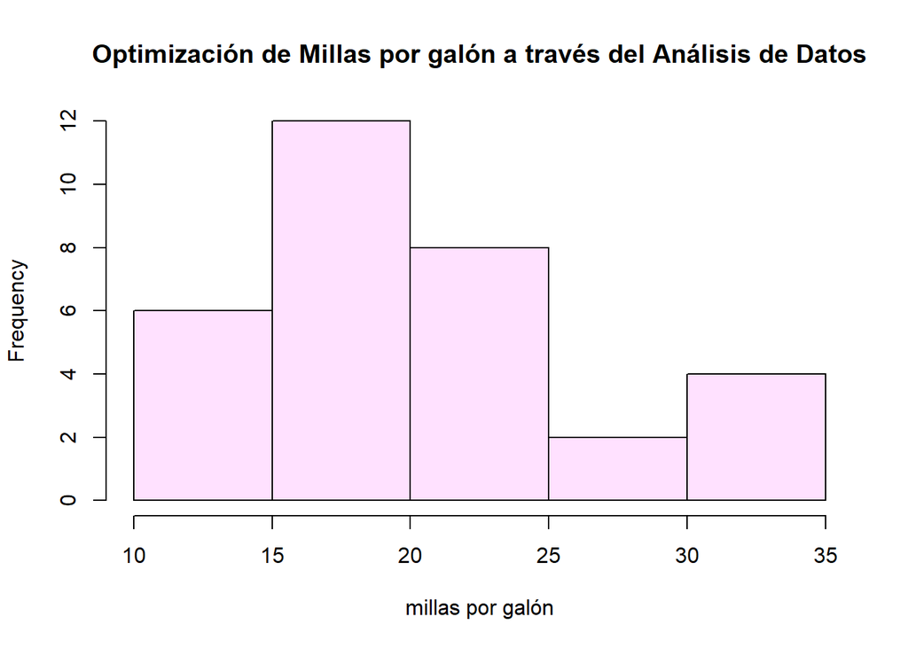

```r
##histograma para millas por galón
data("mtcars")
hist(mtcars$mpg ,main="Optimización de Millas por galón a través del Análisis de Datos",
     xlab= "millas por galón",
     col="thistle1",
     freq=TRUE)
```

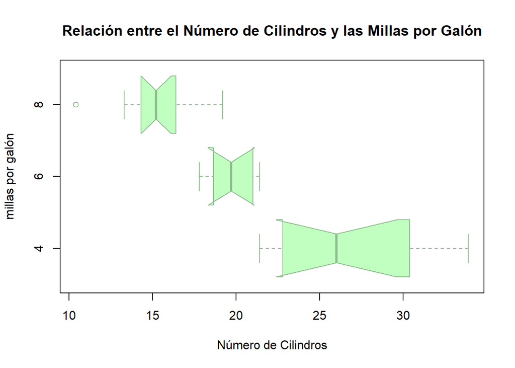

```r
##boxplot
data("mtcars")
boxplot(mtcars$mpg~mtcars$cyl,main= "Relación entre el Número de Cilindros y las Millas por Galón",
        xlab="Número de Cilindros",
        ylab="millas por galón",
        col="darkseagreen1",
        border="darkseagreen",
        horizontal = TRUE,
        notch=TRUE)
```

El diagrama de caja nos presenta distribución de los datos para una variable continua. Esto nos permiten visualizar el centro y la extensión de los datos. Tambien nos permite verificar si existe normalidad o si pueden haber valores atípicos.En este caso se realizo un diagrama de caja para comparar la distribución de millas por galón entre los diferentes números de cilindros.Se puede identificar que los que poseen 4 cilindros tienen una mediana de millas por galón mas alta que los que poseen 6 o 8. Por lo que se puede concluir que conforme aumenta el número de cilindros va a disminuir las millas por galón

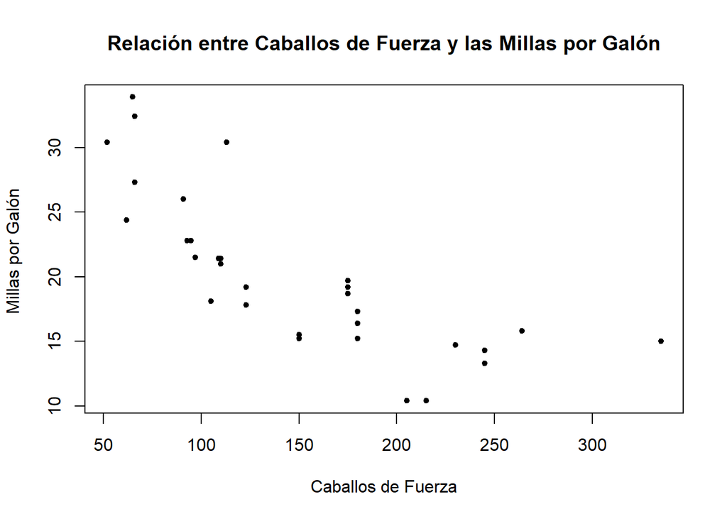

```r
##dispersión
data("mtcars")
plot(mtcars$hp,mtcars$mpg,
     main = "Relación entre Caballos de Fuerza y las Millas por Galón",
     xlab = "Caballos de Fuerza",
     ylab= "Millas por Galón ",
     pch=20)
```

El gráfico de dispersión tiene como función mostrar la relación entre dos variables continuas.En este caso se busca comparar la relación entre caballos de fuerza y millas por galón.Cada punto representa un vehículo. Como se puede observar en el gráfico la dispersión de los puntos significa la variabilidad de los caballos de fuerza y las millas por galón.

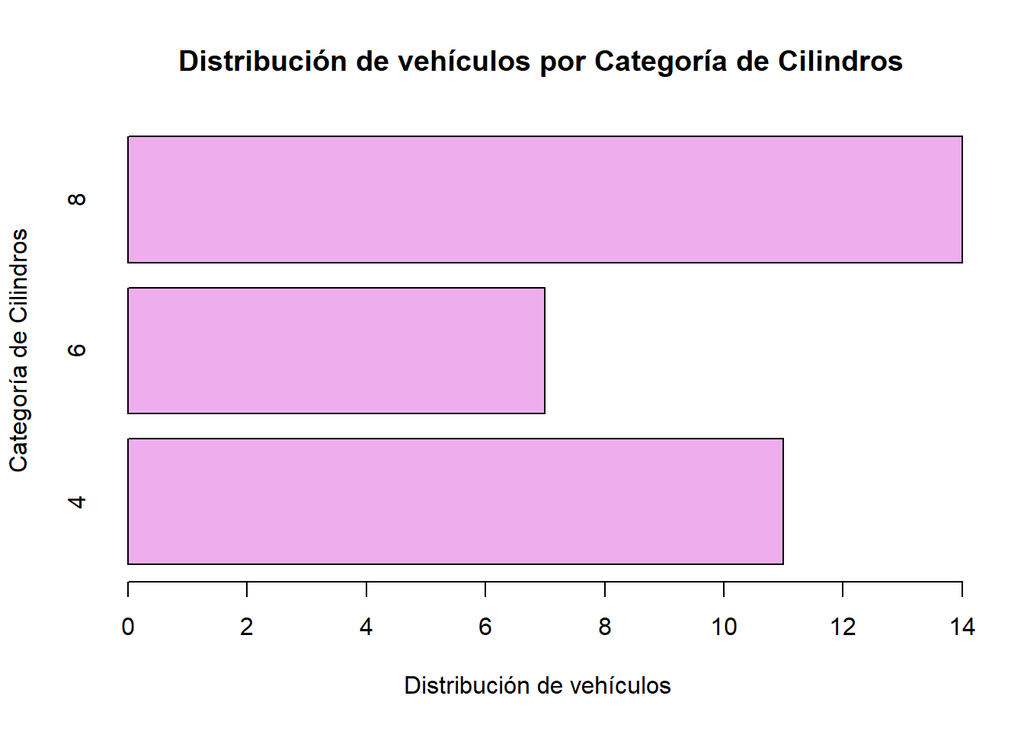

```r
##gráfico de barras
data("mtcars")
cilindros<-table(mtcars$cyl)
barplot(cilindros,main="Distribución de vehículos por Categoría de Cilindros",
        xlab="Distribución de vehículos ",
        ylab="Categoría de Cilindros",
        col="plum2",
        horiz=TRUE)
```

El gráfico de barras tiene como función mostrar de manera resumida un conjunto de datos que puede tener variables cualitativas y continuas. En este caso se busca para mostrar el número de automóviles en cada categoría de cilindros. Se puede concluir que hay tres categorías de cilindros: la 4,6 y 8. Con las longitudes de las barras se puede deducir que la categoría con el mayor número de vehículos (14) es el 8 ,luego el 4 con 11 vehículos y por ultimo el 6 con 7 vehículos.

# Estadística descriptiva

```r
data("mtcars")
media<-mean(mtcars$mpg)
media
```

```
## [1] 20.09062
```

La media es el valor promedio de un conjunto de datos númericos. En este caso se usa esta medida de tendencia central para obtener el promedio de las millas por galón,en este caso es de 20.09

```r
data("mtcars")
mediana<-median(mtcars$mpg)
mediana
```

```
## [1] 19.2
```

La mediana es el valor medio de un conjunto de datos, los cuales se pueden ordenar de forma ascedente o descendente.El resultado obtenido fue de 19.2, el cual corresponde a el punto central de la distribución de millas por galón.

```r
data("mtcars")
varianza<-var(mtcars$mpg)
varianza
```

```
## [1] 36.3241
```

La varianza es una medida de dispersión que representa la variabilidad de un conjunto de datos con respecto a su media.La varianza millas por galón es de 36.3241, esto señala que hay una dispersión considerable.

```r
data("mtcars")
desviación_estándar<-sd(mtcars$mpg)
desviación_estándar
```

```
## [1] 6.026948
```

La desviación estandar es una medida de variabilidad en relación con la media. El resultado obtenido fue de 6.03 indicando que hay una variabilidad considerable en millas por galón.

# Tabla de contigencia

```r
data("mtcars")
tabla_contigencia<-table(mtcars$cyl,mtcars$gear)
tabla_contigencia
```

```
##
##      3  4  5
##   4  1  8  2
##   6  2  4  1
##   8 12  0  2
```

La tabla de contigencia se utiliza para crear al menos dos filas y dos columnas para representar los datos en términos de conteos de frecuencia. Las columnas son las marchas y las filas es el cilindraje. Por ejemplo que hay dos vehiculos con 5 marchas y 4 cilindros.

# Estadística inferencial

```r
t.test(mtcars$mpg,mu=20)
```

```
##
##  One Sample t-test
##
## data:  mtcars$mpg
## t = 0.08506, df = 31, p-value = 0.9328
## alternative hypothesis: true mean is not equal to 20
## 95 percent confidence interval:
##  17.91768 22.26357
## sample estimates:
## mean of x
##  20.09062
```

# Prueba de correlación de Pearson

```r
cor.test(mtcars$hp,mtcars$mpg,method = "pearson")
```

```
##
##  Pearson's product-moment correlation
##
## data:  mtcars$hp and mtcars$mpg
## t = -6.7424, df = 30, p-value = 1.788e-07
## alternative hypothesis: true correlation is not equal to 0
## 95 percent confidence interval:
##  -0.8852686 -0.5860994
## sample estimates:
##        cor
## -0.7761684
```

El coefciente de correlación de pearson es una prueba que se encarga de medir la relación estadistica entre dos variables continuas. Puede tomar un rango de valores de 1 a -1. Se obtuvo un valor de -0.776 que nos indica una correlación fuerte y negativa ;y que a medida que el valor de una variable aumenta el otro disminuye.